# ANOVA Ridgeplots g0 vs g8 GFP distributions

My goal is to figure out whether the GFP distribution of gen8 populations differ significantly from that of stock strains ie. gen0 populations. The populations can have four genotypes: Wildtype GAP1 architecture, LTR KO, ARS KO, or LTR + ARS KO.

Note that here we are using data collected from stock strains from the freezer. not the true g0 populations. I will get flow data from the true g0 populations that we froze.

Instead of ANOVA, I can do t-test between g0 and g8 of each genotype. I’m interested in whether there is a difference between g8 and g0. so 4 t-tests in total because I have 4 genotypes. check whether the GFP distribution is normal - use Shapiro Wilk test. If not normal, use Mann-Whitney.

Additionally, I could do ANOVA between all 8 groups. Null hypothesis they are all part of the same distribution. Will it be able to detect whether ONE group is distinct? Hmm .. I have 4 groups in g0 vs the same 4 groups in g8. 8 groups comparison… or 4 pair-wise comparisons.

Load packages

Set working directory as a new folder - not the folder the .Rmd file sits in. Personal preference.

```r
require("knitr")
opts_knit$set(root.dir = "/Volumes/GoogleDrive/My Drive/greshamlab/projects/EE_GAP1_ArchMuts_Summer2021/analysis/gen0_vs_gen8")
```

```r
getwd()
```

##### Ridgeplots of Stock Strains

###### Draw histograms of the stock strains (g0) to see if CNVs appeared at gen8 or not

Get folder with flow data (FCS files) of stock strains which represents generation 0

```r
stock_folder_path = "/Volumes/GoogleDrive/My Drive/greshamlab/Molecular Determinants of CNV Evolution Dynamics/Summer 2021 Group LTEE/mCitrine CNV reporter test"

g0_files = list.files(paste0(stock_folder_path,"/FCS_files"))
```

```r
#files_pos <- match(sample_sheet$name, g0_files) #find positions of files that match the sample_sheet names
#g0_files[files_pos] #subset of files to read in
```

```r
sample_sheet = read_csv(file = paste0(stock_folder_path,"/sample_sheet.csv"))
sample_sheet = sample_sheet %>%
  mutate(name = paste0(name, ".fcs"))
```

Use CytoexploreR to read in FCS files as a gating set

```r
stocks_gs <- cyto_setup(path = paste0(stock_folder_path,"/FCS_files"), restrict = T, details = F) #must specify a folder, all fcs files will be read
```

Fill the experiment details for the gating set with sample sheet

```r
for(i in 1:length(names(sample_sheet))){
  flowWorkspace::pData(stocks_gs)[names(sample_sheet[i])]<-sample_sheet[i]
}
#view to see if attached
cyto_details(stocks_gs) %>% View()
```

transform stock strain gating set

```r
GFP_trans <- cyto_transformer_logicle(stocks_gs,
                                      channels = c("B2-A"),
                                      widthBasis = -100
)#returns it as a list
FSC_SSC_trans <- cyto_transformer_log(stocks_gs,
                                      channels = c("FSC-A", "FSC-H", "SSC-A", "SSC-H")
)
combined_trans <- cyto_transformer_combine(GFP_trans,FSC_SSC_trans)
transformed_timepoint_gating_set <- cyto_transform(stocks_gs,
                                                   trans = combined_trans)

#apply gating template to stock strain gating set
cyto_gatingTemplate_apply(transformed_timepoint_gating_set, gatingTemplate= "cytek_gating_01_02_04_v2.csv")
```

```r
sc_distributions <- read_csv("sc_distributions_stockStrains.csv")


#do once - get raw single cell flow data of stock strains
timepoint_raw_list <- cyto_extract(transformed_timepoint_gating_set, parent = "Single_cells", raw = T, channels = c("FSC-A", "B2-A")) #raw flow data of each single cell as a list of matrices

sc_distributions <- map_df(timepoint_raw_list, ~as.data.frame(.x), .id="name") %>% #convert to df, put list name in new column
  mutate(name = as.factor(name), #convert `name` to factor
         B2A_FSC = `B2-A`/`FSC-A`
         ) %>% #compute normalized GFP over forward scatter
  left_join(sample_sheet) #join by name column to add other metadata to raw data

#do once - output the file if first time
#write_csv(sc_distributions, "sc_distributions_stockStrains.csv")
```

#### Plot ridgeplots of gen0 strains

```
Warning: Removed 111 rows containing non-finite values (stat_density_ridges).
```

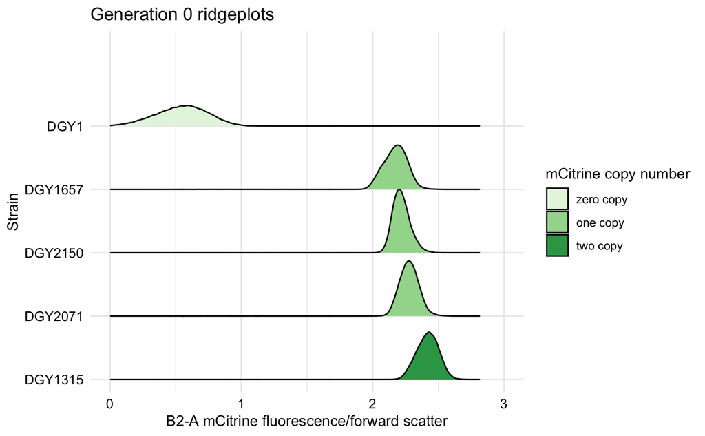

```r
g0_plot
```

Analysis of Generation 8 data #Generation 8 Ridgeplots

```r
g8_sc_distributions <- read_csv("01_02_04_v2_SingleCellDistributions_01_EE_GAP1_ArchMuts_2021.csv")

g8_sc_distributions = g8_sc_distributions %>% mutate(
  generation = factor(generation, levels = unique(g8_sc_distributions$generation)),
  sample = factor(sample, levels = unique(rev(c("ctrl0",
                                                "ctrl1",
                                                "ctrl2",
                                                "gap1_1",
                                                "gap1_2",
                                                "gap1_3",
                                                "gap1_4",
                                                "gap1_5",
                                                "gap1_ltr_1",
                                                "gap1_ltr_2",
                                                "gap1_ltr_3",
                                                "gap1_ltr_4",
                                                "gap1_ltr_5",
                                                "gap1_ltr_6",
                                                "gap1_ltr_7",
                                                "gap1_ltr_8",
                                                "gap1_ars_1",
                                                "gap1_ars_3",
                                                "gap1_ars_4",
                                                "gap1_ars_5",
                                                "gap1_ars_6",
                                                "gap1_ars_7",
                                                "gap1_ars_8",
                                                "gap1_all_1",
                                                "gap1_all_2",
                                                "gap1_all_3",
                                                "gap1_all_4",
                                                "gap1_all_5",
                                                "gap1_all_6",
                                                "gap1_all_7",
                                                "gap1_all_8"
  )
  ))),
  name = factor(name, levels = unique(rev(c("Experiment_042-Plate_001-Reference Group-B3 Unstained (Cells).fcs",
                                            "Experiment_042-Plate_001-1 copy control-D3 DGY500.fcs",
                                            "Experiment_042-Plate_001-Reference Group-F3 DGY1315 mCitrine (Cells).fcs",
                                            "Experiment_042-Plate_001-Experimental-H3 gap1_1.fcs",
                                            "Experiment_042-Plate_001-Experimental-G4 gap1_2.fcs",
                                            "Experiment_042-Plate_001-Experimental-H5 gap1_3.fcs",
                                            "Experiment_042-Plate_001-Experimental-G6 gap1_4.fcs",
                                            "Experiment_042-Plate_001-Experimental-H7 gap1_5.fcs",
                                            "Experiment_042-Plate_001-Experimental-C4 gap1_ltr_1.fcs",
                                            "Experiment_042-Plate_001-Experimental-D5 gap1_ltr_2.fcs",
                                            "Experiment_042-Plate_001-Experimental-C6 gap1_ltr_3.fcs",
                                            "Experiment_042-Plate_001-Experimental-D7 gap1_ltr_4.fcs",
                                            "Experiment_042-Plate_001-Experimental-C8 gap1_ltr_5.fcs",
                                            "Experiment_042-Plate_001-Experimental-B9 gap1_ltr_6.fcs",
                                            "Experiment_042-Plate_001-Experimental-H9 gap1_ltr_7.fcs",
                                            "Experiment_042-Plate_001-Experimental-E10 gap1_ltr_8.fcs",
                                            "Experiment_042-Plate_001-Experimental-D9 gap1_ars_6.fcs",
                                            "Experiment_042-Plate_001-Experimental-E4 gap1_ars_1.fcs",
                                            "Experiment_042-Plate_001-Experimental-E6 gap1_ars_3.fcs",
                                            "Experiment_042-Plate_001-Experimental-F7 gap1_ars_4.fcs",
                                            "Experiment_042-Plate_001-Experimental-E8 gap1_ars_5.fcs",
                                            "Experiment_042-Plate_001-Experimental-D9 gap1_ars_6.fcs",
                                            "Experiment_042-Plate_001-Experimental-A10 gap1_ars_7.fcs",
                                            "Experiment_042-Plate_001-Experimental-G10 gap1_ars_8.fcs",
                                            "Experiment_042-Plate_001-Experimental-A4 gap1_all_1.fcs",
                                            "Experiment_042-Plate_001-Experimental-A6 gap1_all_3.fcs",
                                            "Experiment_042-Plate_001-Experimental-B5 gap1_all_2.fcs",
                                            "Experiment_042-Plate_001-Experimental-B7 gap1_all_4.fcs",
                                            "Experiment_042-Plate_001-Experimental-A8 gap1_all_5.fcs",
                                            "Experiment_042-Plate_001-Experimental-G8 gap1_all_6.fcs",
                                            "Experiment_042-Plate_001-Experimental-F9 gap1_all_7.fcs",
                                            "Experiment_042-Plate_001-Experimental-C10 gap1_all_8.fcs"
  )))))
```

Plot g8 ridgeplots

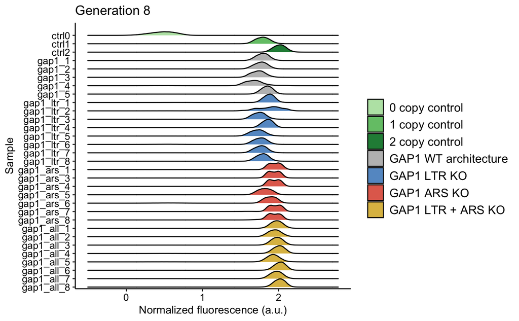

```r
g8plot
```

#### Merge two dataframes

```r
head(g8_sc_distributions)

g0_sc_distr = sc_distributions %>%
  dplyr::filter(Strain %in% c("DGY1657","DGY2071","DGY1","DGY2150","DGY1315")) %>%
  mutate(generation = 0,
        generation = as.factor(generation),
        sample = Description)


g0and8 = bind_rows(g0_sc_distr, g8_sc_distributions) %>%
  select(-Genotype) %>%
  mutate(#Description = as.factor(Description),
         `mCitrine copy number` = as.factor(`mCitrine copy number`))
```

Data Cleaning - Search and Replace strings inside `Description` column

```r
str(g0and8)
unique(g0and8$Description)
g0and8["Description"][g0and8["Description"] == "LTR + ARS KO"] <- "GAP1 LTR + ARS KO"
unique(g0and8$Description)
g0and8["Description"][g0and8["Description"] == "Wildtype architecture"] <- "GAP1 WT architecture"
unique(g0and8$Description)
g0and8["Description"][g0and8["Description"] == "ARS KO"] <- "GAP1 ARS KO"
unique(g0and8$Description)
```

Generation 0 and 8 ridgeplots Edit this graph - so the reorder the samples 0, WT, 2 copy, … gen 0 plots, then gen8 plots in order: WT, LTR, ARS, LTR+ARS. Did we ever freeze down gen 0? Yes PLATE1!!! I should cytek those…make o/n in GLN and CYTEK.  
Maybe the stock strains were grown in YPD . that could explain why the Fluorescence signal looks different. I want to redo this analysis for the true gen0 populations. vs gen8 populations.

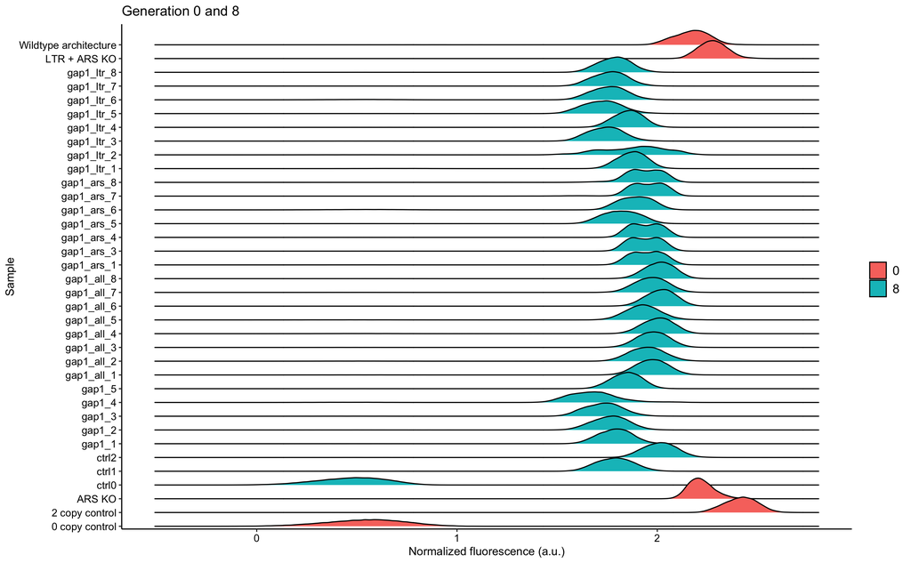

```r
#g0and8 %>% dplyr::filter(is.na(sample)) %>% View()

g0and8plot = ggplot(g0and8, aes(x = B2A_FSC, y = sample, fill = generation)) +
  geom_density_ridges(scale=1.5, quantile_lines = F, quantiles = 2) +
  xlab("Normalized fluorescence (a.u.)") +
  ylab("Sample") +
  ggtitle("Generation 0 and 8") +
  theme_classic() +
  scale_y_discrete(expand = expansion(add = c(0.2, 1.5))) + #expands the graph space or else the top is cut off
  #scale_fill_discrete(breaks=c("0 copy control",
  #                             "1 copy control",
  #                             "2 copy control",
  #                             "GAP1 WT architecture",
  #                             "GAP1 LTR KO",
  #                             "GAP1 ARS KO",
  #                             "GAP1 LTR + ARS KO") #change order of legend items
  #                   )+
  #scale_fill_manual(values=c(RColorBrewer::brewer.pal(4, "Greens")[-1],"gray","#6699cc","#e26d5c","#DEBD52"),
  #                  breaks=c("0 copy control",
  #                           "1 copy control",
  #                           "2 copy control",
  #                           "GAP1 WT architecture",
  #                           "GAP1 LTR KO",
  #                           "GAP1 ARS KO",
  #                           "GAP1 LTR + ARS KO")) +
  #scale_fill_manual(values=c("#DE54B9", "#5474DE", "#54DE79", "#DEBD52")) +  #c(ARS,LTR+ARS,LTR,WT)+
  theme(
    legend.text = element_text(family="Arial", size = 12),#edit legend text font and size
    legend.title = element_blank(), #remove legend title
    axis.text.x = element_text(family="Arial", size = 10, color = "black"), #edit x-tick labels
    axis.text.y = element_text(family="Arial", size = 10, color = "black")
  )
g0and8plot
```

```r
#ggsave("g0and8_ridgeplot_071822.png",bg='#ffffff' )
```

#### Perform ANOVA

or some analysis to detect differences between these 8 groups , or 4 groups across 2 timepoints. We know that the Two Copy Control and One Copy Control are different from each other - and the effect size is small. Could we use that as a control/justification of difference? Say like if the effect size between g0 and g8 is the same as the effect size between the 1copy and 2copy controls?

We have 31 distinct populations. We have 8 populations of the LTR+ARS KO (gap1_all_#)

```r
g8_sc_distributions %>% distinct(sample) %>% arrange(sample)
```

```r
summary(anovaGFPperPop) #prints summary of the model
```

```
                 Df Sum Sq Mean Sq F value              Pr(>F)
sample           30 199793    6660  287542 <0.0000000000000002 ***
Residuals   2889912  66933       0
---
Signif. codes:  0 ‘***’ 0.001 ‘**’ 0.01 ‘*’ 0.05 ‘.’ 0.1 ‘ ’ 1
```

Compare LTR+ARS KO pops to WT Architecture pops

```r
summary(anovAllvsWT) #prints summary of the model
```

```
                 Df Sum Sq Mean Sq F value              Pr(>F)
Description       1  13080   13080  546715 <0.0000000000000002 ***
Residuals   1206924  28876       0
---
Signif. codes:  0 ‘***’ 0.001 ‘**’ 0.01 ‘*’ 0.05 ‘.’ 0.1 ‘ ’ 1
```

```r
ttest_all8ctr2
```

```
    Welch Two Sample t-test

data:  B2A_FSC by sample
t = -4.2143, df = 184410, p-value = 0.00002507
alternative hypothesis: true difference in means between group gap1_all_8 and group ctrl2 is not equal to 0
95 percent confidence interval:
 -0.003166477 -0.001156115
sample estimates:
mean in group gap1_all_8      mean in group ctrl2
                2.007774                 2.009935
```

```r
t.test(`B2A_FSC`~sample, mu = 0, data = all8_ctr1, conf.level = 0.95)
```

```
    Welch Two Sample t-test

data:  B2A_FSC by sample
t = 431.01, df = 185401, p-value < 0.00000000000000022
alternative hypothesis: true difference in means between group gap1_all_8 and group ctrl1 is not equal to 0
95 percent confidence interval:
 0.2210857 0.2231056
sample estimates:
mean in group gap1_all_8      mean in group ctrl1
                2.007774                 1.785678
```

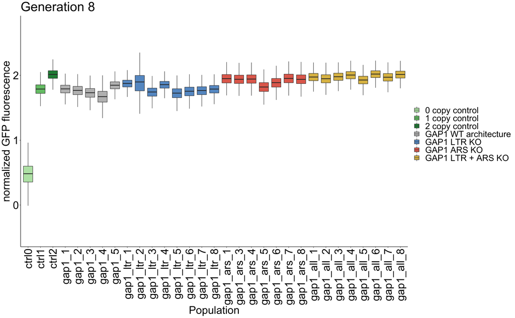

```r
gen8_GFP_boxplot = ggplot(g8_sc_distributions, aes(sample, `B2A_FSC`, fill = Description)) +
  geom_boxplot(outlier.shape = NA) +
  ggtitle("Generation 8") +
  xlab("Population") +
  #scale_fill_manual(values=c("#e26d5c", "#DEBD52", "#6699cc", "gray"))+
  scale_fill_manual(values=c(RColorBrewer::brewer.pal(4, "Greens")[-1],"gray","#6699cc","#e26d5c","#DEBD52"), #colors
                    breaks=c('0 copy control', '1 copy control', '2 copy control', 'GAP1 WT architecture','GAP1 LTR KO','GAP1 ARS KO', 'GAP1 LTR + ARS KO') #change order of legend items
                    ) +
  ylab("normalized GFP fluorescence") +
  scale_x_discrete(limits = rev)+ #reverses the order of boxplot
  #scale_x_discrete(labels=c("Wildtype architecture","LTR KO","ARS KO","LTR and ARS KO"))+
  theme_classic() +
  theme(legend.title = element_blank(),
        axis.text.x = element_text(family="Arial", size = 30, color = "black", angle = 90, vjust = 0.5, hjust=1), #edit x-tick labels
        axis.text.y = element_text(family="Arial", size = 30, color = "black"),
        text = element_text(size=30)
        )

gen8_GFP_boxplot
```

```r
#ggsave("gen8_GFP_boxplot_071922.png",bg='#ffffff' )
```

Clones from g0 and g8 Let’s graph their GFP ridgeplots